# 3 Logistic Regression

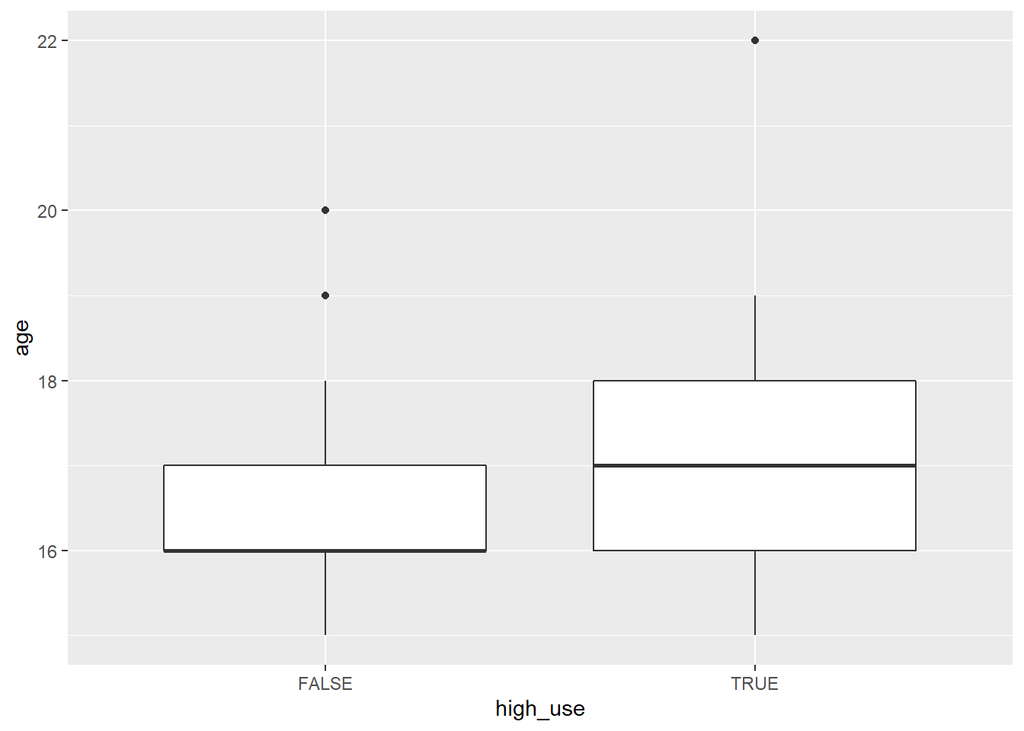

```r
p2 + geom_boxplot()
```

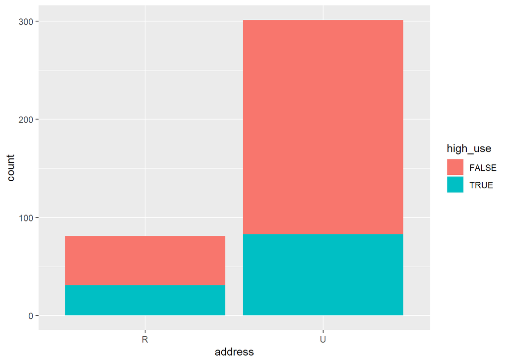

```r
p3 + geom_bar()
```

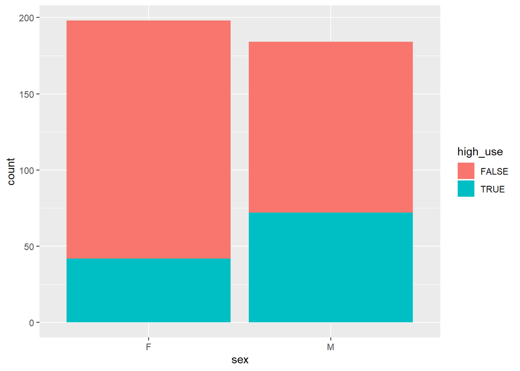

```r
p4 + geom_bar()
```

```r
table(alcs$high_use, alc$sex)
```

```
##
##           F   M
##   FALSE 156 112
##   TRUE   42  72
```

```r
table(alcs$high_use, alc$address)
```

```
##
##           R   U
##   FALSE  50 218
##   TRUE   31  83
```

Based on the explorations, it looks like one of the hypotheses will fail. It looks like there are more heavy drinkers among rural compared to urbam students.

On the next tab, we will get our hand dirty with the regression model.

## Build Logistic regression

```r
# build the model
m <- glm(data=alcs, high_use ~ sex + address + absences + age, family="binomial")
summary(m)
```

```
##
## Call:
## glm(formula = high_use ~ sex + address + absences + age, family = "binomial",
##     data = alcs)
##
## Deviance Residuals:
##     Min       1Q   Median       3Q      Max
## -2.4240  -0.8261  -0.6250   1.0505   2.1305
##
## Coefficients:
##             Estimate Std. Error z value Pr(>|z|)
## (Intercept) -4.00961    1.76034  -2.278   0.0227 *
## sexM         0.98222    0.24136   4.070 4.71e-05 ***
## addressU    -0.41405    0.28094  -1.474   0.1405
## absences     0.09283    0.02325   3.992 6.56e-05 ***
## age          0.15088    0.10240   1.473   0.1406
## ---
## Signif. codes:  0 '***' 0.001 '**' 0.01 '*' 0.05 '.' 0.1 ' ' 1
##
## (Dispersion parameter for binomial family taken to be 1)
##
##     Null deviance: 465.68  on 381  degrees of freedom
## Residual deviance: 424.90  on 377  degrees of freedom
## AIC: 434.9
##
## Number of Fisher Scoring iterations: 4
```

Z-value is a results of a statistical test which tells whether the variables power is statistically significant in the model (if z is >2 or <-2). p-value tells quite the same. We can see, that sex and absences are statistically significant predictors.

```r
# build a new model with only significant predictors
m2 <- glm(data=alcs, high_use ~ sex + absences, family="binomial")

# calculate odd ratios by exponenting the coefficients of the model
OR <- coef(m2) %>% exp
# and the same for confidence intervals
CI <- confint(m2) %>% exp
# print them out
cbind(OR, CI)
```

```
##                   OR     2.5 %    97.5 %
## (Intercept) 0.159445 0.1012577 0.2427684
## sexM        2.658116 1.6710354 4.2863129
## absences    1.101409 1.0549317 1.1548057
```

According to the odds ratio, males are 2.6 times more likely to be high users of alcohol. For every absence, the probability that the student is a heavy drinker is 1.1 times more likely.

.

## Explore the predictive power

```r
# Use prdeict() to compute probabilites based on the logit model.
# type maked the probalities be probalities instead of log of odds, the default
probabilities <- predict(m2, type="response")
# add the probs in the data frame
alcs <- mutate (alcs, probs = probabilities)
# use the probs to make a prediction of high use
# threshold will be set to .5. If we want less false positives, we should increase the threshold
alcs <- mutate(alcs, prediction = probs > .5)
# crosstabs the target versus predictions
table(high_use = alcs$high_use, prediction = alcs$prediction)
```

```
##         prediction
## high_use FALSE TRUE
##    FALSE   258   10
##    TRUE     88   26
```

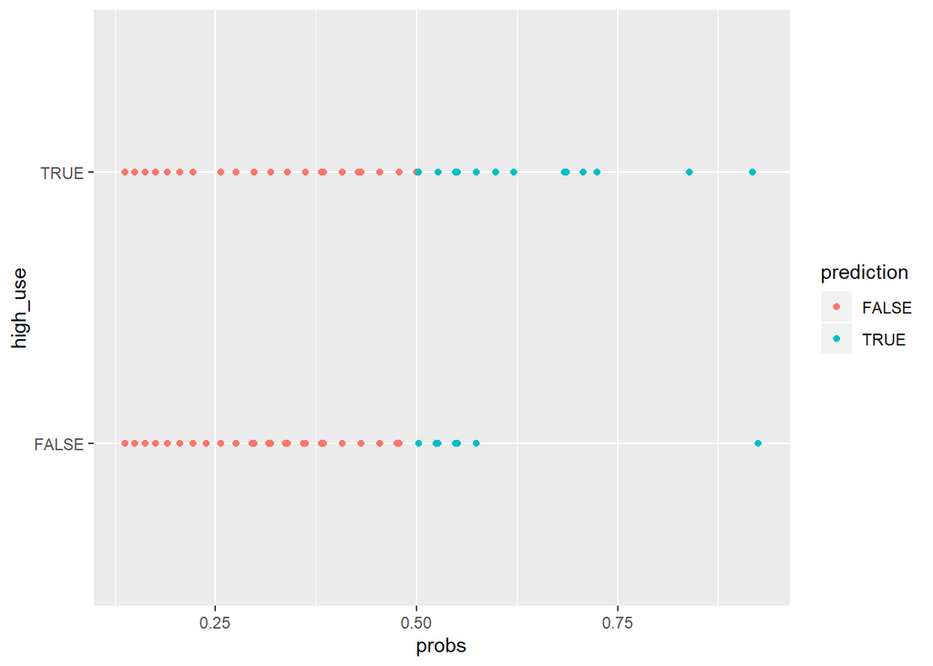

```r
# plot
ggplot(alcs, aes(x = probs, y = high_use, col = prediction)) + geom_point()
```

```r
loss_func <- function(class, prob) {
  n_wrong <- abs(class - prob) > 0.5
  mean(n_wrong)
}
# call the function to compute the average of wrong predictions
loss_func(class = alcs$high_use, prob = alcs$prediction)
```

```
## [1] 0.2565445
```

```r
# 10-fold cross-validation for the model
library(boot)
cv <- cv.glm(data = alcs, cost = loss_func, glmfit = m, K = 10)
# cv.glm computes the error and stores it in delta, print delta
cv$delta[1]
```

```
## [1] 0.2513089
```

Accoring to 10-fold cross-validation, average number of wrong predictions is 0.25. Thus, my model is a bit better than the one in DataCamp (error .26). Wohoo!

.